# SI 618: Data Manipulation and Analysis

## 02 - Introduction to pandas

### Dr. Chris Teplovs, School of Information, University of Michigan

This work is licensed under a [Creative Commons Attribution-NonCommercial-ShareAlike 4.0 International License](http://creativecommons.org/licenses/by-nc-sa/4.0/).

## Objectives:

- Know how to manipulate Series and DataFrame
- Draw a random sample of data
- Select subset of data using boolean masking
- Compute descriptive and summary statistics
- Discretize continuous variables
- Sort Series/DataFrame by index or column
- Group data and calculate aggregate statistics
- Use vectorized string methods
- Make basic plots (scatter plot, histogram, bar chart, etc)

## Submission Instructions:

Please turn in this Jupyter notebook file (both .ipynb and .html formats) on Canvas before you leave the classroom. Try to get through as much as you can.

### IMPORTANT: Replace `?` in the following code with your uniqname.

```python
MY_UNIQNAME = 'feiyi'
```

## Preface

This lab consists of Part 0, Part 1 and Part 2. Part 0 is an introduction to some Pandas basics. There are no points assocaited with Part 0 but we will be covering it in class. Part 1 is based on a survey dataset and Part 2 uses movies and cast data. We will guide you through Part 1, and let you work on Part 2 on your own.

**Question 0 is worth 2 points. Questions 1-12 are worth 1 point each. Questions 13-23 are worth 2 points each.**

### Question 0 (2 points, 0.5 points each):

What is the output of pandas.DataFrame.describe()? (Chapter 5) Generate descriptive statistics that summarize the central tendency, dispersion and shape of a dataset’s distribution.

What is the output of value_counts() work? (Chapter 5) Return a Series containing counts of unique values.

What’s the difference between a series & a dataframe? (Chapter 5) Dataframe is composed of series. Series has one dimension. Dataframe is like a table.

Explain what foo_bar.groupby(’A’).sum() returns (Data Wrangling with Python and Pandas 1.9) Group foo_bar by column 'A' and sum up other columns' values.

## Part 0: Background

[figure not shown]

- less looping over elements
- lots of built-in functionality
- a "paradigm shift"

[figure not shown]

# Data structures

We're all familiar with lists:

```python
names = ["Charlotte", "Ingrid", "Ian", "Eric"]
scores = [80, 95, 85, 70]
```

Now let's say that we wanted to divide each of those scores by two and assign the results to another variable. Go ahead and write some code that does that... There are lots of ways to do this, so go ahead and write one way to do it (without importing any additional python packages) and assign the results to a variable called `half`:

```python
# insert code here
half = []
for i in scores:
    half.append(i/2)
```

If you followed the above instructions, the following cell block should print a list of floats that looks like `[40.0, 47.5, 42.5, 35.0]`

```python
half
```

```
[40.0, 47.5, 42.5, 35.0]
```

We can put data into an array structure that allows us to apply more powerful functions. The data structure that we're interested in is called an `ndarray` and is from the `numpy` package:

```python
import numpy as np
ascores = np.array(scores)
```

```python
ascores
```

```
array([80, 95, 85, 70])
```

```python
ahalf = ascores / 2
```

```python
ahalf
```

```
array([40. , 47.5, 42.5, 35. ])
```

Numpy arrays are powerful, but they have some limitations: they can only consist of one type of data (e.g. int), etc. pandas provides two additional data structures that are built on numpy ndarrays.

The first are Series. Let's create a simple pandas Series and examine it:

```python
import pandas as pd
```

```python
sscores = pd.Series(scores,name='scores')
```

```python
sscores
```

```
0    80
1    95
2    85
3    70
Name: scores, dtype: int64
```

So you see a couple of useful things: an index (0 to 3) and a data type (dtype), which in this case is an int64.

**A Series is a one-dimensional ndarray with axis labels**

```python
data = dict(zip(names,scores))
```

```python
zip(names,scores)
```

```
<zip at 0x2b14b692fc8>
```

```python
data
```

```
{'Charlotte': 80, 'Ingrid': 95, 'Ian': 85, 'Eric': 70}
```

```python
import pandas as pd
```

```python
data
```

```
{'Charlotte': 80, 'Ingrid': 95, 'Ian': 85, 'Eric': 70}
```

```python
sData = pd.Series(data=data,name='score')
```

```python
sData
```

```
Charlotte    80
Ingrid       95
Ian          85
Eric         70
Name: score, dtype: int64
```

So Series are a bit friendlier than numpy arrays, but they're still only one-dimensional. Keep in mind that our basic data abstraction is a table, which can be thought of as a two-dimensional array. Let's go ahead and create a simple DataFrame with just one column:

```python
pd.DataFrame(scores,index=names,columns=['score'])
```

|  | score |
| --- | --- |
| Charlotte | 80 |
| Ingrid | 95 |
| Ian | 85 |
| Eric | 70 |

Let's return to the code we ran last time and walk though it just to make sure we understand it

```python
df_names = pd.read_csv('data/names.csv')
```

Actually, that CSV file was created from a number of smaller CSV files. Here's the code that will load the set of smaller CSV files:

```python
years = range(1880, 2015)
pieces = []
for year in years:
    path = 'data/names/yob%d.csv' % year
    frame = pd.read_csv(path)
    frame['year'] = year
    pieces.append(frame)
df_names = pd.concat(pieces, ignore_index=True)
```

```python
df_names.head()
```

|  | name | gender | birth_count | year |
| --- | --- | --- | --- | --- |
| 0 | Simeon | M | 23 | 1880 |
| 1 | Raoul | M | 7 | 1880 |
| 2 | Lou | M | 14 | 1880 |
| 3 | Myra | F | 83 | 1880 |
| 4 | Alois | M | 10 | 1880 |

Let's discuss what just happened there.

# Part 1 (as a group): Mental Health Disorders In the Tech Workplace

From https://www.kaggle.com/osmi/mental-health-in-tech-survey

## Data Description

This dataset is from a 2014 survey that measures attitudes towards mental health and frequency of mental health disorders in the tech workplace.

## Metadata

**Timestamp**

**Age**

**Gender**

**Country**

**state**: If you live in the United States, which state or territory do you live in?

**self_employed**: Are you self-employed?

**family_history**: Do you have a family history of mental illness?

**treatment**: Have you sought treatment for a mental health condition?

**work_interfere**: If you have a mental health condition, do you feel that it interferes with your work?

**no_employees**: How many employees does your company or organization have?

**remote_work**: Do you work remotely (outside of an office) at least 50% of the time?

**tech_company**: Is your employer primarily a tech company/organization?

**benefits**: Does your employer provide mental health benefits?

**care_options**: Do you know the options for mental health care your employer provides?

**wellness_program**: Has your employer ever discussed mental health as part of an employee wellness program?

**seek_help**: Does your employer provide resources to learn more about mental health issues and how to seek help?

**anonymity**: Is your anonymity protected if you choose to take advantage of mental health or substance abuse treatment resources?

**leave**: How easy is it for you to take medical leave for a mental health condition?

**mental_health_consequence**: Do you think that discussing a mental health issue with your employer would have negative consequences?

**phys_health_consequence**: Do you think that discussing a physical health issue with your employer would have negative consequences?

**coworkers**: Would you be willing to discuss a mental health issue with your coworkers?

**supervisor**: Would you be willing to discuss a mental health issue with your direct supervisor(s)?

**mental_health_interview**: Would you bring up a mental health issue with a potential employer in an interview?

**phys_health_interview**: Would you bring up a physical health issue with a potential employer in an interview?

**mental_vs_physical**: Do you feel that your employer takes mental health as seriously as physical health?

**obs_consequence**: Have you heard of or observed negative consequences for coworkers with mental health conditions in your workplace?

**comments**: Any additional notes or comments

Let's load the usual libraries and also ask for plots to be rendered inside the notebook:

```python
import numpy as np
import pandas as pd
%matplotlib inline
```

Then read the CSV file into a DataFrame:

```python
df = pd.read_csv("data/survey.csv")
```

It's common to look at the resulting DataFrame using .head()

```python
df.head()
```

|  | Timestamp | Age | Gender | Country | state | self_employed | family_history | treatment | work_interfere | no_employees | ... | leave | mental_health_consequence | phys_health_consequence | coworkers | supervisor | mental_health_interview | phys_health_interview | mental_vs_physical | obs_consequence | comments |
| --- | --- | --- | --- | --- | --- | --- | --- | --- | --- | --- | --- | --- | --- | --- | --- | --- | --- | --- | --- | --- | --- |
| 0 | 2014-08-27 11:29:31 | 37 | Female | United States | IL | NaN | No | Yes | Often | 6-25 | ... | Somewhat easy | No | No | Some of them | Yes | No | Maybe | Yes | No | NaN |
| 1 | 2014-08-27 11:29:37 | 44 | M | United States | IN | NaN | No | No | Rarely | More than 1000 | ... | Don't know | Maybe | No | No | No | No | No | Don't know | No | NaN |
| 2 | 2014-08-27 11:29:44 | 32 | Male | Canada | NaN | NaN | No | No | Rarely | 6-25 | ... | Somewhat difficult | No | No | Yes | Yes | Yes | Yes | No | No | NaN |
| 3 | 2014-08-27 11:29:46 | 31 | Male | United Kingdom | NaN | NaN | Yes | Yes | Often | 26-100 | ... | Somewhat difficult | Yes | Yes | Some of them | No | Maybe | Maybe | No | Yes | NaN |
| 4 | 2014-08-27 11:30:22 | 31 | Male | United States | TX | NaN | No | No | Never | 100-500 | ... | Don't know | No | No | Some of them | Yes | Yes | Yes | Don't know | No | NaN |

5 rows × 27 columns

If you want to look at a random sample, you can use .sample()

```python
df.sample(5)
```

|  | Timestamp | Age | Gender | Country | state | self_employed | family_history | treatment | work_interfere | no_employees | ... | leave | mental_health_consequence | phys_health_consequence | coworkers | supervisor | mental_health_interview | phys_health_interview | mental_vs_physical | obs_consequence | comments |
| --- | --- | --- | --- | --- | --- | --- | --- | --- | --- | --- | --- | --- | --- | --- | --- | --- | --- | --- | --- | --- | --- |
| 1034 | 2014-08-29 11:01:41 | 36 | M | United States | MN | No | No | No | Never | 100-500 | ... | Don't know | Yes | Maybe | No | No | No | Maybe | Don't know | Yes | NaN |
| 1178 | 2014-09-26 08:45:56 | 40 | m | China | NaN | Yes | No | No | Sometimes | 1-5 | ... | Somewhat easy | No | No | Some of them | Some of them | Maybe | Maybe | Don't know | No | NaN |
| 451 | 2014-08-27 15:53:59 | 40 | Genderqueer | United States | VA | No | Yes | No | Never | More than 1000 | ... | Don't know | Yes | Maybe | No | Some of them | No | Maybe | Yes | No | NaN |
| 922 | 2014-08-28 20:31:02 | 28 | Male | United States | CA | No | Yes | Yes | Sometimes | 26-100 | ... | Don't know | Maybe | Maybe | Some of them | Some of them | No | No | Yes | No | NaN |
| 522 | 2014-08-27 17:15:25 | 35 | Male | United States | AZ | No | No | No | NaN | More than 1000 | ... | Don't know | Maybe | Maybe | No | No | No | No | No | No | NaN |

5 rows × 27 columns

Finally, you can get some basic information about the size and shape of the DataFrame:

```python
print("The number of rows of the dataset is: ", len(df))
print("The number of columns of the dataset is: ", len(df.columns))
print("The shape of the dataset is: ", df.shape)
```

```
The number of rows of the dataset is:  1259
The number of columns of the dataset is:  27
The shape of the dataset is:  (1259, 27)
```

You can list the columns:

```python
df.columns
```

```
Index(['Timestamp', 'Age', 'Gender', 'Country', 'state', 'self_employed',
       'family_history', 'treatment', 'work_interfere', 'no_employees',
       'remote_work', 'tech_company', 'benefits', 'care_options',
       'wellness_program', 'seek_help', 'anonymity', 'leave',
       'mental_health_consequence', 'phys_health_consequence', 'coworkers',
       'supervisor', 'mental_health_interview', 'phys_health_interview',
       'mental_vs_physical', 'obs_consequence', 'comments'],
      dtype='object')
```

And you can extract one or more columns. The following pair of commands do exactly the same thing:

```python
print(df['Country'])
```

```
0        United States
1        United States
2               Canada
3       United Kingdom
4        United States
5        United States
6        United States
7               Canada
8        United States
9               Canada
10       United States
11            Bulgaria
12       United States
13       United States
14              Canada
```

[output cut: 47 more lines]

```python
country_state = df[['Country','state']]
country_state.head()
```

|  | Country | state |
| --- | --- | --- |
| 0 | United States | IL |
| 1 | United States | IN |
| 2 | Canada | NaN |
| 3 | United Kingdom | NaN |
| 4 | United States | TX |

## Extracting rows

```python
df.iloc[0]
```

```
Timestamp                    2014-08-27 11:29:31
Age                                           37
Gender                                    Female
Country                            United States
state                                         IL
self_employed                                NaN
family_history                                No
treatment                                    Yes
work_interfere                             Often
no_employees                                6-25
remote_work                                   No
tech_company                                 Yes
benefits                                     Yes
care_options                            Not sure
wellness_program                              No
seek_help                                    Yes
anonymity                                    Yes
leave                              Somewhat easy
mental_health_consequence                     No
phys_health_consequence                       No
coworkers                           Some of them
supervisor                                   Yes
mental_health_interview                       No
phys_health_interview                      Maybe
mental_vs_physical                           Yes
obs_consequence                               No
comments                                     NaN
Name: 0, dtype: object
```

```python
df.loc[0]
```

```
Timestamp                    2014-08-27 11:29:31
Age                                           37
Gender                                    Female
Country                            United States
state                                         IL
self_employed                                NaN
family_history                                No
treatment                                    Yes
work_interfere                             Often
no_employees                                6-25
remote_work                                   No
tech_company                                 Yes
benefits                                     Yes
care_options                            Not sure
wellness_program                              No
seek_help                                    Yes
anonymity                                    Yes
leave                              Somewhat easy
mental_health_consequence                     No
phys_health_consequence                       No
coworkers                           Some of them
supervisor                                   Yes
mental_health_interview                       No
phys_health_interview                      Maybe
mental_vs_physical                           Yes
obs_consequence                               No
comments                                     NaN
Name: 0, dtype: object
```

```python
df_gender = df.set_index('Gender')
```

```python
df_gender.loc['Male']
```

| Gender | Timestamp | Age | Country | state | self_employed | family_history | treatment | work_interfere | no_employees | remote_work | ... | leave | mental_health_consequence | phys_health_consequence | coworkers | supervisor | mental_health_interview | phys_health_interview | mental_vs_physical | obs_consequence | comments |
| --- | --- | --- | --- | --- | --- | --- | --- | --- | --- | --- | --- | --- | --- | --- | --- | --- | --- | --- | --- | --- | --- |
| Male | 2014-08-27 11:29:44 | 32 | Canada | NaN | NaN | No | No | Rarely | 6-25 | No | ... | Somewhat difficult | No | No | Yes | Yes | Yes | Yes | No | No | NaN |
| Male | 2014-08-27 11:29:46 | 31 | United Kingdom | NaN | NaN | Yes | Yes | Often | 26-100 | No | ... | Somewhat difficult | Yes | Yes | Some of them | No | Maybe | Maybe | No | Yes | NaN |
| Male | 2014-08-27 11:30:22 | 31 | United States | TX | NaN | No | No | Never | 100-500 | Yes | ... | Don't know | No | No | Some of them | Yes | Yes | Yes | Don't know | No | NaN |
| Male | 2014-08-27 11:31:22 | 33 | United States | TN | NaN | Yes | No | Sometimes | 6-25 | No | ... | Don't know | No | No | Yes | Yes | No | Maybe | Don't know | No | NaN |
| Male | 2014-08-27 11:32:43 | 23 | Canada | NaN | NaN | No | No | Never | 26-100 | No | ... | Don't know | No | No | Yes | Yes | Maybe | Maybe | Yes | No | NaN |
| Male | 2014-08-27 11:32:44 | 31 | United States | OH | NaN | No | Yes | Sometimes | 6-25 | Yes | ... | Don't know | No | No | Some of them | Yes | No | No | Don't know | No | NaN |
| Male | 2014-08-27 11:33:26 | 36 | United States | CT | NaN | Yes | No | Never | 500-1000 | No | ... | Don't know | No | No | Yes | Yes | No | No | Don't know | No | I'm not on my company's health insurance which... |
| Male | 2014-08-27 11:33:57 | 27 | Canada | NaN | NaN | No | No | Never | 6-25 | No | ... | Somewhat easy | No | No | Some of them | Some of them | Maybe | Yes | Yes | No | NaN |
| Male | 2014-08-27 11:34:20 | 23 | United Kingdom | NaN | NaN | No | Yes | Sometimes | 26-100 | Yes | ... | Very easy | Maybe | No | Some of them | No | Maybe | Maybe | No | No | My company does provide healthcare but not to ... |
| Male | 2014-08-27 11:34:37 | 32 | United States | TN | NaN | No | Yes | Sometimes | 6-25 | No | ... | Don't know | Maybe | No | Some of them | Yes | No | No | No | No | NaN |
| Male | 2014-08-27 11:35:08 | 36 | France | NaN | Yes | Yes | No | NaN | 6-25 | Yes | ... | Somewhat easy | No | No | Some of them | Some of them | Maybe | Maybe | Don't know | No | NaN |
| Male | 2014-08-27 11:35:12 | 29 | United States | NY | No | Yes | Yes | Sometimes | 100-500 | No | ... | Somewhat difficult | Maybe | No | Some of them | Some of them | No | No | No | No | NaN |
| Male | 2014-08-27 11:35:48 | 46 | United States | MA | No | No | Yes | Often | 26-100 | Yes | ... | Don't know | Maybe | No | Some of them | Yes | No | Maybe | No | No | NaN |
| Male | 2014-08-27 11:36:24 | 41 | United States | IA | No | No | Yes | Never | More than 1000 | No | ... | Don't know | Maybe | No | No | No | No | Yes | Don't know | No | NaN |
| Male | 2014-08-27 11:38:18 | 37 | United Kingdom | NaN | No | No | No | Sometimes | 6-25 | No | ... | Very difficult | Yes | Maybe | Some of them | No | No | Maybe | No | No | NaN |
| Male | 2014-08-27 11:39:03 | 32 | United Kingdom | NaN | No | No | No | Never | 6-25 | Yes | ... | Don't know | Yes | Yes | Some of them | Some of them | No | Maybe | No | No | NaN |
| Male | 2014-08-27 11:38:55 | 31 | United States | PA | Yes | Yes | No | Rarely | 1-5 | Yes | ... | Somewhat difficult | Yes | No | No | No | No | No | No | Yes | NaN |
| Male | 2014-08-27 11:39:36 | 42 | United States | WA | No | Yes | Yes | Sometimes | 26-100 | Yes | ... | Very easy | Maybe | No | Some of them | Some of them | Maybe | Yes | Don't know | No | I selected my current employer based on its po... |
| Male | 2014-08-27 11:41:17 | 27 | United States | NY | No | No | Yes | Rarely | 6-25 | No | ... | Very easy | No | No | Yes | Yes | Maybe | Maybe | Don't know | No | NaN |
| Male | 2014-08-27 11:41:37 | 29 | Canada | NaN | No | No | No | Rarely | 1-5 | No | ... | Very easy | Yes | Maybe | Some of them | No | No | No | Don't know | No | NaN |
| Male | 2014-08-27 11:41:50 | 38 | Portugal | NaN | No | No | No | NaN | 100-500 | No | ... | Somewhat easy | Maybe | No | Some of them | Some of them | No | Maybe | No | No | NaN |
| Male | 2014-08-27 11:42:25 | 24 | United Kingdom | NaN | No | No | Yes | Sometimes | 6-25 | No | ... | Don't know | Maybe | Maybe | Some of them | No | No | Yes | No | Yes | NaN |
| Male | 2014-08-27 11:42:31 | 35 | United States | MI | No | No | No | NaN | More than 1000 | Yes | ... | Somewhat difficult | Yes | Yes | Some of them | No | No | Maybe | Don't know | No | NaN |
| Male | 2014-08-27 11:43:07 | 27 | Canada | NaN | No | Yes | Yes | Sometimes | 1-5 | No | ... | Very difficult | Maybe | No | Some of them | No | No | No | Yes | No | NaN |
| Male | 2014-08-27 11:43:10 | 18 | Netherlands | NaN | No | No | No | Often | 6-25 | No | ... | Somewhat difficult | Yes | Maybe | No | Some of them | No | No | No | No | NaN |
| Male | 2014-08-27 11:43:22 | 30 | United States | IN | No | No | Yes | Sometimes | 26-100 | No | ... | Don't know | No | No | No | No | No | Maybe | Don't know | No | NaN |
| Male | 2014-08-27 11:43:45 | 28 | United Kingdom | NaN | No | No | No | NaN | 26-100 | No | ... | Don't know | No | Maybe | Some of them | Yes | Maybe | Yes | Don't know | No | NaN |
| Male | 2014-08-27 11:43:48 | 34 | United States | TN | No | No | No | NaN | 6-25 | No | ... | Don't know | No | No | Yes | Yes | Maybe | Yes | Don't know | No | NaN |
| Male | 2014-08-27 11:45:32 | 33 | United States | UT | No | No | No | NaN | 100-500 | Yes | ... | Don't know | No | No | Some of them | Yes | Maybe | Maybe | Don't know | No | NaN |
| Male | 2014-08-27 11:45:51 | 32 | United States | TN | No | No | No | Never | 1-5 | Yes | ... | Don't know | Maybe | No | Some of them | Yes | No | No | Don't know | No | NaN |
| ... | ... | ... | ... | ... | ... | ... | ... | ... | ... | ... | ... | ... | ... | ... | ... | ... | ... | ... | ... | ... | ... |
| Male | 2015-02-21 04:41:28 | 32 | United States | TX | No | No | Yes | Often | 26-100 | Yes | ... | Very difficult | Yes | Maybe | Some of them | No | No | No | Don't know | No | NaN |
| Male | 2015-02-21 04:55:11 | 28 | Australia | NaN | No | No | Yes | Often | 100-500 | Yes | ... | Don't know | Yes | No | No | No | No | Maybe | No | No | NaN |
| Male | 2015-02-21 05:34:27 | 31 | Brazil | NaN | Yes | No | Yes | NaN | 1-5 | No | ... | Don't know | No | No | Yes | Yes | No | Maybe | Don't know | No | NaN |
| Male | 2015-02-21 05:55:13 | 24 | United Kingdom | NaN | No | No | No | NaN | 100-500 | No | ... | Somewhat easy | Maybe | Maybe | Some of them | Yes | No | Maybe | Don't know | No | NaN |
| Male | 2015-02-21 05:55:17 | 34 | Ireland | NaN | No | Yes | Yes | Never | 1-5 | Yes | ... | Don't know | Maybe | No | Some of them | Yes | No | No | Don't know | No | NaN |
| Male | 2015-02-21 06:19:41 | 34 | United Kingdom | NaN | No | Yes | No | Often | 26-100 | Yes | ... | Somewhat easy | Maybe | No | Some of them | Yes | Maybe | Yes | Yes | No | NaN |
| Male | 2015-02-21 08:21:36 | 23 | United States | TX | No | No | Yes | Sometimes | 1-5 | No | ... | Very easy | Maybe | Maybe | Some of them | Yes | No | No | No | No | NaN |
| Male | 2015-02-21 08:54:40 | 33 | Czech Republic | NaN | No | Yes | No | Often | 100-500 | No | ... | Somewhat easy | No | No | Some of them | Yes | Maybe | Maybe | Don't know | Yes | NaN |
| Male | 2015-02-21 09:19:12 | 31 | Philippines | NaN | No | No | No | Sometimes | More than 1000 | No | ... | Very difficult | Yes | Yes | Some of them | No | No | Maybe | No | Yes | NaN |
| Male | 2015-02-21 09:22:23 | 33 | United States | FL | No | No | Yes | Often | 26-100 | Yes | ... | Don't know | Maybe | No | Some of them | No | No | Maybe | Don't know | No | NaN |
| Male | 2015-02-21 09:30:14 | 27 | United Kingdom | NaN | No | No | No | Rarely | More than 1000 | Yes | ... | Don't know | No | No | Some of them | Yes | No | No | Don't know | No | NaN |
| Male | 2015-02-21 09:48:13 | 38 | United States | TX | No | No | Yes | Sometimes | More than 1000 | Yes | ... | Very easy | No | No | Yes | Yes | No | No | Don't know | No | I openly discuss my mental health struggles. I... |
| Male | 2015-02-21 10:00:50 | 46 | United States | CA | No | Yes | Yes | Often | 26-100 | No | ... | Don't know | Maybe | No | Some of them | No | No | No | No | No | NaN |
| Male | 2015-02-21 17:19:18 | 39 | Netherlands | NaN | No | No | No | NaN | More than 1000 | No | ... | Somewhat easy | Maybe | Maybe | No | Some of them | No | No | Yes | No | NaN |
| Male | 2015-02-21 18:59:05 | 25 | United States | MN | No | Yes | Yes | Sometimes | 26-100 | No | ... | Somewhat easy | Yes | No | Some of them | Some of them | No | Maybe | Don't know | No | NaN |
| Male | 2015-02-22 02:40:32 | 39 | Greece | NaN | No | No | No | NaN | 6-25 | Yes | ... | Don't know | Yes | No | No | No | No | No | Don't know | No | NaN |
| Male | 2015-02-24 09:00:56 | 25 | United Kingdom | NaN | No | Yes | Yes | Sometimes | More than 1000 | No | ... | Very easy | No | No | Yes | Yes | Yes | Yes | Yes | No | I work at a large university with a track reco... |
| Male | 2015-02-24 09:13:49 | 23 | United Kingdom | NaN | No | No | Yes | Rarely | 6-25 | No | ... | Don't know | No | No | Yes | Yes | No | Maybe | Don't know | No | NaN |
| Male | 2015-02-24 09:18:25 | 23 | Canada | NaN | No | No | Yes | Often | 26-100 | No | ... | Don't know | Maybe | No | Yes | Some of them | No | No | Don't know | No | NaN |
| Male | 2015-02-24 10:32:32 | 60 | United States | CA | No | No | Yes | Often | More than 1000 | Yes | ... | Somewhat easy | Maybe | Maybe | Some of them | No | No | Maybe | Don't know | No | NaN |
| Male | 2015-04-02 15:47:43 | 28 | United States | TN | No | Yes | Yes | Often | More than 1000 | No | ... | Somewhat easy | Yes | Maybe | Some of them | Yes | No | No | No | Yes | NaN |
| Male | 2015-04-11 14:35:22 | 31 | Poland | NaN | Yes | No | Yes | Often | 6-25 | Yes | ... | Somewhat easy | Maybe | No | Some of them | No | No | No | Don't know | No | NaN |
| Male | 2015-04-23 14:03:51 | 28 | Ireland | NaN | No | No | Yes | Rarely | 26-100 | No | ... | Don't know | Maybe | No | No | No | No | Maybe | Don't know | No | NaN |
| Male | 2015-05-06 10:14:50 | 22 | Australia | NaN | No | Yes | Yes | Often | 100-500 | No | ... | Don't know | Maybe | Maybe | No | Yes | No | Maybe | Don't know | Yes | In australia all organisations of a certain si... |
| Male | 2015-05-06 16:55:58 | 32 | United States | OR | No | No | No | Never | 100-500 | No | ... | Somewhat easy | No | No | No | Some of them | Maybe | Yes | Don't know | No | NaN |
| Male | 2015-07-27 23:25:34 | 30 | United States | CA | Yes | Yes | Yes | Often | 26-100 | No | ... | Don't know | No | No | Some of them | Yes | Maybe | Maybe | Yes | No | NaN |
| Male | 2015-08-17 09:38:35 | 36 | South Africa | NaN | No | Yes | Yes | Often | 100-500 | No | ... | Somewhat easy | No | No | Some of them | Yes | No | Yes | Yes | No | NaN |
| Male | 2015-08-25 19:59:38 | 36 | United States | UT | No | Yes | No | Rarely | More than 1000 | No | ... | Somewhat easy | Maybe | Maybe | Some of them | Some of them | No | No | Don't know | No | NaN |
| Male | 2015-09-26 01:07:35 | 32 | United States | IL | No | Yes | Yes | Often | 26-100 | Yes | ... | Somewhat difficult | No | No | Some of them | Yes | No | No | Yes | No | NaN |
| Male | 2016-02-01 23:04:31 | 25 | United States | IL | No | Yes | Yes | Sometimes | 26-100 | No | ... | Don't know | Maybe | No | Some of them | No | No | No | Don't know | No | NaN |

615 rows × 26 columns

```python
df.iloc['Gender'] # generates error
```

[output not shown]

```python
df.iloc[0]
```

```
Timestamp                    2014-08-27 11:29:31
Age                                           37
Gender                                    Female
Country                            United States
state                                         IL
self_employed                                NaN
family_history                                No
treatment                                    Yes
work_interfere                             Often
no_employees                                6-25
remote_work                                   No
tech_company                                 Yes
benefits                                     Yes
care_options                            Not sure
wellness_program                              No
seek_help                                    Yes
anonymity                                    Yes
leave                              Somewhat easy
mental_health_consequence                     No
phys_health_consequence                       No
coworkers                           Some of them
supervisor                                   Yes
mental_health_interview                       No
phys_health_interview                      Maybe
mental_vs_physical                           Yes
obs_consequence                               No
comments                                     NaN
Name: 0, dtype: object
```

## Sorting

You can use either sort_values() or sort_index():

```python
df_sorted = df.sort_values('Age')
df_sorted.head(10)
```

|  | Timestamp | Age | Gender | Country | state | self_employed | family_history | treatment | work_interfere | no_employees | ... | leave | mental_health_consequence | phys_health_consequence | coworkers | supervisor | mental_health_interview | phys_health_interview | mental_vs_physical | obs_consequence | comments |
| --- | --- | --- | --- | --- | --- | --- | --- | --- | --- | --- | --- | --- | --- | --- | --- | --- | --- | --- | --- | --- | --- |
| 715 | 2014-08-28 10:07:53 | -1726 | male | United Kingdom | NaN | No | No | Yes | Sometimes | 26-100 | ... | Somewhat difficult | Yes | No | No | No | No | Maybe | Don't know | No | NaN |
| 143 | 2014-08-27 12:39:14 | -29 | Male | United States | MN | No | No | No | NaN | More than 1000 | ... | Don't know | No | No | Some of them | Yes | No | No | Don't know | No | NaN |
| 1127 | 2014-08-30 20:55:11 | -1 | p | United States | AL | Yes | Yes | Yes | Often | 1-5 | ... | Very easy | Yes | Yes | Yes | Yes | Yes | Yes | Yes | Yes | password: testered |
| 734 | 2014-08-28 10:35:55 | 5 | Male | United States | OH | No | No | No | NaN | 100-500 | ... | Somewhat easy | No | No | Yes | Yes | No | No | Yes | No | We had a developer suffer from depression and ... |
| 989 | 2014-08-29 09:10:58 | 8 | A little about you | Bahamas, The | IL | Yes | Yes | Yes | Often | 1-5 | ... | Very easy | Yes | Yes | Yes | Yes | Yes | Yes | Yes | Yes |  |
| 1090 | 2014-08-29 17:26:15 | 11 | male | United States | OH | Yes | No | No | Never | 1-5 | ... | Very easy | No | No | Some of them | Some of them | No | Maybe | Yes | No | NaN |
| 282 | 2014-08-27 14:10:15 | 18 | male | United States | TX | No | No | Yes | Sometimes | 6-25 | ... | Don't know | Yes | No | No | No | No | Maybe | Don't know | No | NaN |
| 287 | 2014-08-27 14:11:55 | 18 | Male | United States | WA | No | No | No | Never | 26-100 | ... | Very easy | No | No | Some of them | Some of them | No | Maybe | Yes | No | NaN |
| 43 | 2014-08-27 11:43:10 | 18 | Male | Netherlands | NaN | No | No | No | Often | 6-25 | ... | Somewhat difficult | Yes | Maybe | No | Some of them | No | No | No | No | NaN |
| 482 | 2014-08-27 16:19:05 | 18 | Female | United Kingdom | NaN | No | Yes | Yes | Sometimes | 1-5 | ... | Don't know | Maybe | Maybe | Some of them | Some of them | Maybe | Maybe | Don't know | No | I don't have a job :D |

10 rows × 27 columns

## Filtering using Boolean Masking

```python
df.Age
```

```
0       37
1       44
2       32
3       31
4       31
5       33
6       35
7       39
8       42
9       23
10      31
11      29
12      42
13      36
14      27
```

[output cut: 47 more lines]

```python
df['Age'] > 0
```

```
0       True
1       True
2       True
3       True
4       True
5       True
6       True
7       True
8       True
9       True
10      True
11      True
12      True
13      True
14      True
```

[output cut: 47 more lines]

```python
df[df['Age'] > 0]
```

|  | Timestamp | Age | Gender | Country | state | self_employed | family_history | treatment | work_interfere | no_employees | ... | leave | mental_health_consequence | phys_health_consequence | coworkers | supervisor | mental_health_interview | phys_health_interview | mental_vs_physical | obs_consequence | comments |
| --- | --- | --- | --- | --- | --- | --- | --- | --- | --- | --- | --- | --- | --- | --- | --- | --- | --- | --- | --- | --- | --- |
| 0 | 2014-08-27 11:29:31 | 37 | Female | United States | IL | NaN | No | Yes | Often | 6-25 | ... | Somewhat easy | No | No | Some of them | Yes | No | Maybe | Yes | No | NaN |
| 1 | 2014-08-27 11:29:37 | 44 | M | United States | IN | NaN | No | No | Rarely | More than 1000 | ... | Don't know | Maybe | No | No | No | No | No | Don't know | No | NaN |
| 2 | 2014-08-27 11:29:44 | 32 | Male | Canada | NaN | NaN | No | No | Rarely | 6-25 | ... | Somewhat difficult | No | No | Yes | Yes | Yes | Yes | No | No | NaN |
| 3 | 2014-08-27 11:29:46 | 31 | Male | United Kingdom | NaN | NaN | Yes | Yes | Often | 26-100 | ... | Somewhat difficult | Yes | Yes | Some of them | No | Maybe | Maybe | No | Yes | NaN |
| 4 | 2014-08-27 11:30:22 | 31 | Male | United States | TX | NaN | No | No | Never | 100-500 | ... | Don't know | No | No | Some of them | Yes | Yes | Yes | Don't know | No | NaN |
| 5 | 2014-08-27 11:31:22 | 33 | Male | United States | TN | NaN | Yes | No | Sometimes | 6-25 | ... | Don't know | No | No | Yes | Yes | No | Maybe | Don't know | No | NaN |
| 6 | 2014-08-27 11:31:50 | 35 | Female | United States | MI | NaN | Yes | Yes | Sometimes | 1-5 | ... | Somewhat difficult | Maybe | Maybe | Some of them | No | No | No | Don't know | No | NaN |
| 7 | 2014-08-27 11:32:05 | 39 | M | Canada | NaN | NaN | No | No | Never | 1-5 | ... | Don't know | No | No | No | No | No | No | No | No | NaN |
| 8 | 2014-08-27 11:32:39 | 42 | Female | United States | IL | NaN | Yes | Yes | Sometimes | 100-500 | ... | Very difficult | Maybe | No | Yes | Yes | No | Maybe | No | No | NaN |
| 9 | 2014-08-27 11:32:43 | 23 | Male | Canada | NaN | NaN | No | No | Never | 26-100 | ... | Don't know | No | No | Yes | Yes | Maybe | Maybe | Yes | No | NaN |
| 10 | 2014-08-27 11:32:44 | 31 | Male | United States | OH | NaN | No | Yes | Sometimes | 6-25 | ... | Don't know | No | No | Some of them | Yes | No | No | Don't know | No | NaN |
| 11 | 2014-08-27 11:32:49 | 29 | male | Bulgaria | NaN | NaN | No | No | Never | 100-500 | ... | Don't know | No | No | Yes | Yes | Yes | Yes | Don't know | No | NaN |
| 12 | 2014-08-27 11:33:23 | 42 | female | United States | CA | NaN | Yes | Yes | Sometimes | 26-100 | ... | Somewhat difficult | Yes | Yes | Yes | Yes | Maybe | Maybe | No | Yes | NaN |
| 13 | 2014-08-27 11:33:26 | 36 | Male | United States | CT | NaN | Yes | No | Never | 500-1000 | ... | Don't know | No | No | Yes | Yes | No | No | Don't know | No | I'm not on my company's health insurance which... |
| 14 | 2014-08-27 11:33:57 | 27 | Male | Canada | NaN | NaN | No | No | Never | 6-25 | ... | Somewhat easy | No | No | Some of them | Some of them | Maybe | Yes | Yes | No | NaN |
| 15 | 2014-08-27 11:34:00 | 29 | female | United States | IL | NaN | Yes | Yes | Rarely | 26-100 | ... | Somewhat easy | No | No | Yes | Some of them | Maybe | Maybe | Don't know | No | I have chronic low-level neurological issues t... |
| 16 | 2014-08-27 11:34:20 | 23 | Male | United Kingdom | NaN | NaN | No | Yes | Sometimes | 26-100 | ... | Very easy | Maybe | No | Some of them | No | Maybe | Maybe | No | No | My company does provide healthcare but not to ... |
| 17 | 2014-08-27 11:34:37 | 32 | Male | United States | TN | NaN | No | Yes | Sometimes | 6-25 | ... | Don't know | Maybe | No | Some of them | Yes | No | No | No | No | NaN |
| 18 | 2014-08-27 11:34:53 | 46 | male | United States | MD | Yes | Yes | No | Sometimes | 1-5 | ... | Very easy | No | No | Yes | Yes | No | Yes | Yes | Yes | NaN |
| 19 | 2014-08-27 11:35:08 | 36 | Male | France | NaN | Yes | Yes | No | NaN | 6-25 | ... | Somewhat easy | No | No | Some of them | Some of them | Maybe | Maybe | Don't know | No | NaN |
| 20 | 2014-08-27 11:35:12 | 29 | Male | United States | NY | No | Yes | Yes | Sometimes | 100-500 | ... | Somewhat difficult | Maybe | No | Some of them | Some of them | No | No | No | No | NaN |
| 21 | 2014-08-27 11:35:24 | 31 | male | United States | NC | Yes | No | No | Never | 1-5 | ... | Somewhat difficult | No | No | Some of them | Some of them | No | Maybe | Yes | No | NaN |
| 22 | 2014-08-27 11:35:48 | 46 | Male | United States | MA | No | No | Yes | Often | 26-100 | ... | Don't know | Maybe | No | Some of them | Yes | No | Maybe | No | No | NaN |
| 23 | 2014-08-27 11:36:24 | 41 | Male | United States | IA | No | No | Yes | Never | More than 1000 | ... | Don't know | Maybe | No | No | No | No | Yes | Don't know | No | NaN |
| 24 | 2014-08-27 11:36:48 | 33 | male | United States | CA | No | Yes | Yes | Rarely | 26-100 | ... | Don't know | No | No | Yes | Yes | No | Yes | Don't know | No | Relatively new job. Ask again later |
| 25 | 2014-08-27 11:37:08 | 35 | male | United States | TN | No | Yes | Yes | Sometimes | More than 1000 | ... | Very easy | Yes | No | Some of them | Yes | No | Yes | No | No | Sometimes I think about using drugs for my me... |
| 26 | 2014-08-27 11:37:23 | 33 | male | United States | TN | No | No | No | NaN | 1-5 | ... | Don't know | Maybe | Maybe | Some of them | No | No | No | Don't know | No | NaN |
| 27 | 2014-08-27 11:37:59 | 35 | Female | United States | CA | No | Yes | Yes | Rarely | 6-25 | ... | Don't know | No | No | Yes | Yes | Maybe | Maybe | Yes | No | NaN |
| 28 | 2014-08-27 11:38:12 | 34 | male | United States | OH | No | No | Yes | Sometimes | 26-100 | ... | Somewhat difficult | No | No | Some of them | No | No | No | No | No | NaN |
| 29 | 2014-08-27 11:38:18 | 37 | Male | United Kingdom | NaN | No | No | No | Sometimes | 6-25 | ... | Very difficult | Yes | Maybe | Some of them | No | No | Maybe | No | No | NaN |
| ... | ... | ... | ... | ... | ... | ... | ... | ... | ... | ... | ... | ... | ... | ... | ... | ... | ... | ... | ... | ... | ... |
| 1229 | 2015-02-22 02:40:32 | 39 | Male | Greece | NaN | No | No | No | NaN | 6-25 | ... | Don't know | Yes | No | No | No | No | No | Don't know | No | NaN |
| 1230 | 2015-02-24 08:54:35 | 23 | Female | United Kingdom | NaN | No | Yes | Yes | Sometimes | 6-25 | ... | Very easy | No | No | Yes | Yes | Maybe | Maybe | Yes | No | NaN |
| 1231 | 2015-02-24 08:58:08 | 24 | Cis Man | United Kingdom | NaN | Yes | No | Yes | Sometimes | 6-25 | ... | Don't know | Maybe | Maybe | Some of them | Some of them | No | Maybe | Don't know | Yes | NaN |
| 1232 | 2015-02-24 09:00:56 | 25 | Male | United Kingdom | NaN | No | Yes | Yes | Sometimes | More than 1000 | ... | Very easy | No | No | Yes | Yes | Yes | Yes | Yes | No | I work at a large university with a track reco... |
| 1233 | 2015-02-24 09:13:49 | 23 | Male | United Kingdom | NaN | No | No | Yes | Rarely | 6-25 | ... | Don't know | No | No | Yes | Yes | No | Maybe | Don't know | No | NaN |
| 1234 | 2015-02-24 09:15:13 | 24 | ostensibly male, unsure what that really means | United Kingdom | NaN | No | No | Yes | Sometimes | 6-25 | ... | Don't know | Yes | Maybe | No | No | No | Maybe | Don't know | No | i'm in a country with social health care so my... |
| 1235 | 2015-02-24 09:18:25 | 23 | Male | Canada | NaN | No | No | Yes | Often | 26-100 | ... | Don't know | Maybe | No | Yes | Some of them | No | No | Don't know | No | NaN |
| 1236 | 2015-02-24 10:32:32 | 60 | Male | United States | CA | No | No | Yes | Often | More than 1000 | ... | Somewhat easy | Maybe | Maybe | Some of them | No | No | Maybe | Don't know | No | NaN |
| 1237 | 2015-02-26 05:44:16 | 28 | male | Ireland | NaN | No | No | No | Sometimes | 26-100 | ... | Don't know | Yes | Maybe | No | No | No | No | No | Yes | NaN |
| 1238 | 2015-04-02 15:47:43 | 28 | Male | United States | TN | No | Yes | Yes | Often | More than 1000 | ... | Somewhat easy | Yes | Maybe | Some of them | Yes | No | No | No | Yes | NaN |
| 1239 | 2015-04-04 11:22:05 | 30 | male | Netherlands | NaN | No | No | No | Sometimes | 500-1000 | ... | Don't know | Maybe | No | Yes | Yes | Maybe | Yes | Don't know | No | NaN |
| 1240 | 2015-04-06 14:58:29 | 31 | male | Germany | NaN | No | Yes | Yes | Sometimes | 100-500 | ... | Somewhat easy | No | No | Some of them | No | No | No | Don't know | No | NaN |
| 1241 | 2015-04-11 14:35:22 | 31 | Male | Poland | NaN | Yes | No | Yes | Often | 6-25 | ... | Somewhat easy | Maybe | No | Some of them | No | No | No | Don't know | No | NaN |
| 1242 | 2015-04-23 14:03:51 | 28 | Male | Ireland | NaN | No | No | Yes | Rarely | 26-100 | ... | Don't know | Maybe | No | No | No | No | Maybe | Don't know | No | NaN |
| 1243 | 2015-05-05 14:22:18 | 43 | f | United States | FL | No | Yes | Yes | Rarely | More than 1000 | ... | Don't know | No | No | Some of them | Yes | No | No | Don't know | No | NaN |
| 1244 | 2015-05-05 15:16:25 | 32 | female | United Kingdom | NaN | No | No | No | NaN | More than 1000 | ... | Don't know | Maybe | No | Some of them | Yes | No | Yes | No | No | NaN |
| 1245 | 2015-05-06 10:14:50 | 22 | Male | Australia | NaN | No | Yes | Yes | Often | 100-500 | ... | Don't know | Maybe | Maybe | No | Yes | No | Maybe | Don't know | Yes | In australia all organisations of a certain si... |
| 1246 | 2015-05-06 16:55:58 | 32 | Male | United States | OR | No | No | No | Never | 100-500 | ... | Somewhat easy | No | No | No | Some of them | Maybe | Yes | Don't know | No | NaN |
| 1247 | 2015-05-07 10:08:50 | 36 | male | Finland | NaN | No | No | Yes | Often | 6-25 | ... | Very difficult | Yes | No | Some of them | No | No | Maybe | Don't know | Yes | NaN |
| 1248 | 2015-06-25 12:24:31 | 41 | Female | United States | WA | No | Yes | Yes | Sometimes | 26-100 | ... | Don't know | Yes | Maybe | No | No | No | No | Don't know | No | NaN |
| 1249 | 2015-07-22 18:57:54 | 30 | M | United States | CA | No | Yes | Yes | Sometimes | 26-100 | ... | Very easy | No | No | Yes | Yes | Maybe | Maybe | Yes | No | Bipolar disorder |
| 1250 | 2015-07-27 23:25:34 | 30 | Male | United States | CA | Yes | Yes | Yes | Often | 26-100 | ... | Don't know | No | No | Some of them | Yes | Maybe | Maybe | Yes | No | NaN |
| 1251 | 2015-08-17 09:38:35 | 36 | Male | South Africa | NaN | No | Yes | Yes | Often | 100-500 | ... | Somewhat easy | No | No | Some of them | Yes | No | Yes | Yes | No | NaN |
| 1252 | 2015-08-20 16:52:09 | 29 | male | United States | NC | No | Yes | Yes | Sometimes | 100-500 | ... | Don't know | Yes | No | Some of them | No | No | Maybe | No | No | NaN |
| 1253 | 2015-08-25 19:59:38 | 36 | Male | United States | UT | No | Yes | No | Rarely | More than 1000 | ... | Somewhat easy | Maybe | Maybe | Some of them | Some of them | No | No | Don't know | No | NaN |
| 1254 | 2015-09-12 11:17:21 | 26 | male | United Kingdom | NaN | No | No | Yes | NaN | 26-100 | ... | Somewhat easy | No | No | Some of them | Some of them | No | No | Don't know | No | NaN |
| 1255 | 2015-09-26 01:07:35 | 32 | Male | United States | IL | No | Yes | Yes | Often | 26-100 | ... | Somewhat difficult | No | No | Some of them | Yes | No | No | Yes | No | NaN |
| 1256 | 2015-11-07 12:36:58 | 34 | male | United States | CA | No | Yes | Yes | Sometimes | More than 1000 | ... | Somewhat difficult | Yes | Yes | No | No | No | No | No | No | NaN |
| 1257 | 2015-11-30 21:25:06 | 46 | f | United States | NC | No | No | No | NaN | 100-500 | ... | Don't know | Yes | No | No | No | No | No | No | No | NaN |
| 1258 | 2016-02-01 23:04:31 | 25 | Male | United States | IL | No | Yes | Yes | Sometimes | 26-100 | ... | Don't know | Maybe | No | Some of them | No | No | No | Don't know | No | NaN |

1256 rows × 27 columns

```python
df['Age'] > 40
```

```
0       False
1        True
2       False
3       False
4       False
5       False
6       False
7       False
8        True
9       False
10      False
11      False
12       True
13      False
14      False
```

[output cut: 47 more lines]

```python
df[  df['Age'] > 40  ]
```

|  | Timestamp | Age | Gender | Country | state | self_employed | family_history | treatment | work_interfere | no_employees | ... | leave | mental_health_consequence | phys_health_consequence | coworkers | supervisor | mental_health_interview | phys_health_interview | mental_vs_physical | obs_consequence | comments |
| --- | --- | --- | --- | --- | --- | --- | --- | --- | --- | --- | --- | --- | --- | --- | --- | --- | --- | --- | --- | --- | --- |
| 1 | 2014-08-27 11:29:37 | 44 | M | United States | IN | NaN | No | No | Rarely | More than 1000 | ... | Don't know | Maybe | No | No | No | No | No | Don't know | No | NaN |
| 8 | 2014-08-27 11:32:39 | 42 | Female | United States | IL | NaN | Yes | Yes | Sometimes | 100-500 | ... | Very difficult | Maybe | No | Yes | Yes | No | Maybe | No | No | NaN |
| 12 | 2014-08-27 11:33:23 | 42 | female | United States | CA | NaN | Yes | Yes | Sometimes | 26-100 | ... | Somewhat difficult | Yes | Yes | Yes | Yes | Maybe | Maybe | No | Yes | NaN |
| 18 | 2014-08-27 11:34:53 | 46 | male | United States | MD | Yes | Yes | No | Sometimes | 1-5 | ... | Very easy | No | No | Yes | Yes | No | Yes | Yes | Yes | NaN |
| 22 | 2014-08-27 11:35:48 | 46 | Male | United States | MA | No | No | Yes | Often | 26-100 | ... | Don't know | Maybe | No | Some of them | Yes | No | Maybe | No | No | NaN |
| 23 | 2014-08-27 11:36:24 | 41 | Male | United States | IA | No | No | Yes | Never | More than 1000 | ... | Don't know | Maybe | No | No | No | No | Yes | Don't know | No | NaN |
| 33 | 2014-08-27 11:39:36 | 42 | Male | United States | WA | No | Yes | Yes | Sometimes | 26-100 | ... | Very easy | Maybe | No | Some of them | Some of them | Maybe | Yes | Don't know | No | I selected my current employer based on its po... |
| 38 | 2014-08-27 11:42:08 | 50 | M | United States | IN | No | No | No | NaN | 100-500 | ... | Don't know | No | No | Some of them | Yes | No | Maybe | Don't know | No | NaN |
| 60 | 2014-08-27 11:48:57 | 44 | Male | United States | IA | No | Yes | Yes | Sometimes | More than 1000 | ... | Don't know | Yes | Maybe | Some of them | No | No | Maybe | Don't know | Yes | NaN |
| 101 | 2014-08-27 12:18:38 | 44 | Female | United States | MA | No | No | No | Never | 100-500 | ... | Don't know | Maybe | Maybe | No | Some of them | No | No | Don't know | No | NaN |
| 112 | 2014-08-27 12:31:03 | 45 | male | United States | MO | No | Yes | Yes | Rarely | 6-25 | ... | Very easy | No | No | Yes | Yes | Yes | Yes | Yes | No | NaN |
| 167 | 2014-08-27 12:48:29 | 42 | male | United States | CA | No | No | No | NaN | 6-25 | ... | Very difficult | Maybe | No | Yes | Yes | No | Maybe | No | No | NaN |
| 178 | 2014-08-27 12:51:25 | 45 | F | United States | CA | No | No | Yes | Sometimes | 1-5 | ... | Somewhat difficult | No | No | Yes | Yes | No | No | Yes | No | In small startups it is very hard to keep ment... |
| 183 | 2014-08-27 12:51:55 | 45 | M | United States | CA | No | No | Yes | Sometimes | More than 1000 | ... | Don't know | Yes | Yes | Some of them | Some of them | No | No | Don't know | No | NaN |
| 184 | 2014-08-27 12:52:08 | 43 | Male | United States | WA | No | Yes | Yes | Often | More than 1000 | ... | Very difficult | Yes | Maybe | No | No | No | No | No | No | NaN |
| 202 | 2014-08-27 12:58:10 | 41 | male | United States | FL | No | No | Yes | Often | 6-25 | ... | Very difficult | Maybe | Maybe | Some of them | Some of them | Maybe | Maybe | Don't know | No | NaN |
| 219 | 2014-08-27 13:09:39 | 41 | Male (CIS) | United States | VA | No | No | No | NaN | 26-100 | ... | Very easy | Yes | No | No | Some of them | No | No | Don't know | No | NaN |
| 231 | 2014-08-27 13:23:38 | 41 | Male | United States | TX | No | No | Yes | Rarely | 500-1000 | ... | Don't know | Maybe | Maybe | Some of them | No | Maybe | Maybe | No | No | I found it difficult to answer all of the ques... |
| 257 | 2014-08-27 13:47:27 | 42 | Male | United States | WA | No | No | No | Never | 6-25 | ... | Somewhat easy | No | No | Some of them | Yes | No | No | Yes | No | No benefits at this organization but my employ... |
| 264 | 2014-08-27 13:53:44 | 43 | Male | Canada | NaN | Yes | No | No | NaN | 6-25 | ... | Somewhat easy | Maybe | No | Yes | Yes | Yes | Yes | Don't know | No | NaN |
| 266 | 2014-08-27 13:54:00 | 41 | Male | United States | AL | No | No | Yes | Sometimes | 26-100 | ... | Very easy | No | No | Yes | Yes | Yes | Yes | Yes | No | I think I am very lucky in my workplace. Our C... |
| 292 | 2014-08-27 14:15:13 | 45 | male | United States | NY | No | Yes | Yes | Sometimes | More than 1000 | ... | Don't know | Maybe | No | Some of them | Some of them | No | Maybe | Don't know | No | NaN |
| 294 | 2014-08-27 14:15:57 | 56 | Male | United States | NaN | No | No | Yes | Never | More than 1000 | ... | Don't know | No | Maybe | Yes | Some of them | No | Maybe | Don't know | No | NaN |
| 297 | 2014-08-27 14:18:41 | 60 | male | United States | CA | No | No | No | NaN | More than 1000 | ... | Don't know | No | No | Some of them | Yes | Maybe | Maybe | Yes | No | NaN |
| 320 | 2014-08-27 14:28:41 | 41 | Male | United States | SD | No | Yes | Yes | Rarely | 100-500 | ... | Somewhat easy | No | No | Some of them | Yes | Maybe | Maybe | Yes | No | NaN |
| 333 | 2014-08-27 14:37:33 | 45 | Male | Ireland | NaN | Yes | No | Yes | Often | 1-5 | ... | Very difficult | No | No | No | No | No | No | Don't know | No | NaN |
| 335 | 2014-08-27 14:37:46 | 46 | M | United States | WA | No | No | No | Never | 26-100 | ... | Very easy | No | No | Some of them | Some of them | Maybe | Maybe | Don't know | No | NaN |
| 347 | 2014-08-27 14:45:45 | 54 | M | United States | CA | No | Yes | Yes | Never | More than 1000 | ... | Don't know | No | No | No | Yes | No | No | Don't know | No | NaN |
| 364 | 2014-08-27 15:05:21 | 329 | Male | United States | OH | No | No | Yes | Often | 6-25 | ... | Don't know | Maybe | No | Some of them | No | No | No | No | No | NaN |
| 371 | 2014-08-27 15:20:53 | 41 | m | United States | WA | No | Yes | Yes | Often | More than 1000 | ... | Somewhat difficult | Maybe | No | Yes | Some of them | No | Maybe | No | Yes | NaN |
| ... | ... | ... | ... | ... | ... | ... | ... | ... | ... | ... | ... | ... | ... | ... | ... | ... | ... | ... | ... | ... | ... |
| 1054 | 2014-08-29 11:39:33 | 42 | M | United States | TN | No | No | No | Rarely | More than 1000 | ... | Don't know | Maybe | No | Some of them | No | No | Maybe | No | No | NaN |
| 1062 | 2014-08-29 12:00:33 | 44 | M | United States | FL | Yes | No | No | Never | 1-5 | ... | Somewhat difficult | No | No | No | No | No | No | Don't know | No | NaN |
| 1068 | 2014-08-29 12:45:11 | 48 | Male | United States | IN | No | No | No | Never | 26-100 | ... | Don't know | Maybe | No | Some of them | Yes | No | Maybe | Don't know | No | NaN |
| 1071 | 2014-08-29 13:17:33 | 43 | Male | United States | OH | No | No | No | Sometimes | More than 1000 | ... | Don't know | Maybe | No | No | No | No | No | Don't know | No | NaN |
| 1072 | 2014-08-29 13:23:40 | 41 | M | United States | IL | No | No | No | Rarely | More than 1000 | ... | Don't know | Maybe | Maybe | Some of them | No | No | No | Yes | Yes | NaN |
| 1076 | 2014-08-29 14:31:00 | 43 | Male | United States | VA | Yes | Yes | Yes | Sometimes | 1-5 | ... | Don't know | Maybe | Maybe | Some of them | Some of them | No | Maybe | Don't know | No | This survey was tough as a self-employed indiv... |
| 1086 | 2014-08-29 16:51:31 | 41 | male | Germany | NaN | No | No | Yes | Sometimes | More than 1000 | ... | Somewhat difficult | No | No | Yes | Yes | No | No | Yes | No | NaN |
| 1091 | 2014-08-29 17:32:31 | 43 | male | United States | TX | No | Yes | No | Never | 100-500 | ... | Somewhat easy | Maybe | No | Some of them | Some of them | No | Maybe | No | No | NaN |
| 1099 | 2014-08-29 20:53:58 | 43 | Male | United States | NY | No | No | No | Never | 500-1000 | ... | Don't know | No | No | Yes | Some of them | No | No | Yes | No | NaN |
| 1104 | 2014-08-29 23:51:01 | 45 | M | United States | CA | No | No | No | Never | 6-25 | ... | Don't know | Yes | Maybe | Some of them | No | No | Maybe | Don't know | No | NaN |
| 1106 | 2014-08-30 03:55:19 | 50 | male | France | NaN | Yes | No | Yes | Sometimes | 26-100 | ... | Don't know | Maybe | Maybe | Some of them | Yes | No | No | Don't know | No | NaN |
| 1117 | 2014-08-30 15:57:04 | 46 | Male | United States | PA | No | Yes | Yes | Sometimes | 6-25 | ... | Don't know | Yes | Maybe | No | Some of them | No | Maybe | Don't know | No | NaN |
| 1121 | 2014-08-30 19:35:58 | 44 | Male | United Kingdom | NaN | No | No | Yes | Sometimes | More than 1000 | ... | Don't know | Maybe | No | Some of them | Some of them | No | No | No | No | NaN |
| 1123 | 2014-08-30 20:12:33 | 45 | female | United States | MI | No | No | Yes | Rarely | 26-100 | ... | Don't know | No | No | Some of them | Some of them | No | Maybe | Don't know | No | NaN |
| 1130 | 2014-08-31 15:03:12 | 42 | F | United States | WA | No | Yes | Yes | Sometimes | 26-100 | ... | Don't know | Yes | No | Some of them | Some of them | No | Yes | No | No | NaN |
| 1137 | 2014-09-01 06:53:28 | 41 | M | United Kingdom | NaN | No | Yes | No | NaN | 6-25 | ... | Somewhat difficult | Maybe | Maybe | Some of them | Some of them | Maybe | Maybe | Don't know | No | NaN |
| 1159 | 2014-09-03 01:32:51 | 51 | M | Singapore | NaN | No | No | No | Never | More than 1000 | ... | Don't know | Yes | No | No | No | No | No | No | No | NaN |
| 1164 | 2014-09-04 23:42:28 | 46 | Female | United States | CA | No | No | Yes | Often | 100-500 | ... | Don't know | Maybe | No | Some of them | Some of them | No | Maybe | No | No | NaN |
| 1182 | 2014-10-02 21:25:16 | 72 | Female | United States | IN | No | Yes | Yes | Never | 500-1000 | ... | Somewhat easy | Maybe | Maybe | Some of them | Yes | No | No | Don't know | Yes | NaN |
| 1186 | 2014-11-06 11:24:38 | 56 | female | United States | OR | Yes | No | No | Rarely | 1-5 | ... | Don't know | Maybe | Maybe | No | No | No | No | Don't know | No | I'm self-employed on contract with small start... |
| 1190 | 2015-01-03 03:38:30 | 44 | M | United States | OH | No | Yes | Yes | Sometimes | 100-500 | ... | Don't know | Maybe | No | Some of them | Some of them | No | No | Don't know | No | My mental health issues were the direct result... |
| 1211 | 2015-02-21 09:16:45 | 45 | male | Ireland | NaN | No | No | No | Never | More than 1000 | ... | Don't know | Yes | No | Yes | Some of them | No | No | No | Yes | NaN |
| 1217 | 2015-02-21 09:30:29 | 42 | male | Ireland | NaN | No | No | No | Never | 26-100 | ... | Somewhat difficult | Yes | Yes | Some of them | Some of them | No | No | No | No | NaN |
| 1220 | 2015-02-21 10:00:50 | 46 | Male | United States | CA | No | Yes | Yes | Often | 26-100 | ... | Don't know | Maybe | No | Some of them | No | No | No | No | No | NaN |
| 1221 | 2015-02-21 10:45:51 | 46 | male | United States | MD | No | Yes | Yes | Sometimes | 100-500 | ... | Don't know | No | No | Some of them | Yes | Yes | Yes | Don't know | No | Just starting a new job hence the numerous I d... |
| 1222 | 2015-02-21 11:48:52 | 41 | female | Netherlands | NaN | Yes | No | Yes | Rarely | 1-5 | ... | Somewhat easy | No | No | Yes | Yes | Yes | Yes | Yes | No | The data will be skewed for self-employed peop... |
| 1236 | 2015-02-24 10:32:32 | 60 | Male | United States | CA | No | No | Yes | Often | More than 1000 | ... | Somewhat easy | Maybe | Maybe | Some of them | No | No | Maybe | Don't know | No | NaN |
| 1243 | 2015-05-05 14:22:18 | 43 | f | United States | FL | No | Yes | Yes | Rarely | More than 1000 | ... | Don't know | No | No | Some of them | Yes | No | No | Don't know | No | NaN |
| 1248 | 2015-06-25 12:24:31 | 41 | Female | United States | WA | No | Yes | Yes | Sometimes | 26-100 | ... | Don't know | Yes | Maybe | No | No | No | No | Don't know | No | NaN |
| 1257 | 2015-11-30 21:25:06 | 46 | f | United States | NC | No | No | No | NaN | 100-500 | ... | Don't know | Yes | No | No | No | No | No | No | No | NaN |

150 rows × 27 columns

### Example: Find people who reported a family history of mental health conditions. </font>

Solution:

```python
family_history_mask = df.family_history=='Yes'
df[family_history_mask].tail(5)
```

|  | Timestamp | Age | Gender | Country | state | self_employed | family_history | treatment | work_interfere | no_employees | ... | leave | mental_health_consequence | phys_health_consequence | coworkers | supervisor | mental_health_interview | phys_health_interview | mental_vs_physical | obs_consequence | comments |
| --- | --- | --- | --- | --- | --- | --- | --- | --- | --- | --- | --- | --- | --- | --- | --- | --- | --- | --- | --- | --- | --- |
| 1252 | 2015-08-20 16:52:09 | 29 | male | United States | NC | No | Yes | Yes | Sometimes | 100-500 | ... | Don't know | Yes | No | Some of them | No | No | Maybe | No | No | NaN |
| 1253 | 2015-08-25 19:59:38 | 36 | Male | United States | UT | No | Yes | No | Rarely | More than 1000 | ... | Somewhat easy | Maybe | Maybe | Some of them | Some of them | No | No | Don't know | No | NaN |
| 1255 | 2015-09-26 01:07:35 | 32 | Male | United States | IL | No | Yes | Yes | Often | 26-100 | ... | Somewhat difficult | No | No | Some of them | Yes | No | No | Yes | No | NaN |
| 1256 | 2015-11-07 12:36:58 | 34 | male | United States | CA | No | Yes | Yes | Sometimes | More than 1000 | ... | Somewhat difficult | Yes | Yes | No | No | No | No | No | No | NaN |
| 1258 | 2016-02-01 23:04:31 | 25 | Male | United States | IL | No | Yes | Yes | Sometimes | 26-100 | ... | Don't know | Maybe | No | Some of them | No | No | No | Don't know | No | NaN |

5 rows × 27 columns

You can use a simple expression like `df[df['family_history'] == 'Yes']` or you can make more complex boolean expressions using parentheses:

```python
df_filtered = df[(df['family_history'] == 'Yes') & (df['treatment'] == 'Yes')]
df_filtered.head()
```

|  | Timestamp | Age | Gender | Country | state | self_employed | family_history | treatment | work_interfere | no_employees | ... | leave | mental_health_consequence | phys_health_consequence | coworkers | supervisor | mental_health_interview | phys_health_interview | mental_vs_physical | obs_consequence | comments |
| --- | --- | --- | --- | --- | --- | --- | --- | --- | --- | --- | --- | --- | --- | --- | --- | --- | --- | --- | --- | --- | --- |
| 3 | 2014-08-27 11:29:46 | 31 | Male | United Kingdom | NaN | NaN | Yes | Yes | Often | 26-100 | ... | Somewhat difficult | Yes | Yes | Some of them | No | Maybe | Maybe | No | Yes | NaN |
| 6 | 2014-08-27 11:31:50 | 35 | Female | United States | MI | NaN | Yes | Yes | Sometimes | 1-5 | ... | Somewhat difficult | Maybe | Maybe | Some of them | No | No | No | Don't know | No | NaN |
| 8 | 2014-08-27 11:32:39 | 42 | Female | United States | IL | NaN | Yes | Yes | Sometimes | 100-500 | ... | Very difficult | Maybe | No | Yes | Yes | No | Maybe | No | No | NaN |
| 12 | 2014-08-27 11:33:23 | 42 | female | United States | CA | NaN | Yes | Yes | Sometimes | 26-100 | ... | Somewhat difficult | Yes | Yes | Yes | Yes | Maybe | Maybe | No | Yes | NaN |
| 15 | 2014-08-27 11:34:00 | 29 | female | United States | IL | NaN | Yes | Yes | Rarely | 26-100 | ... | Somewhat easy | No | No | Yes | Some of them | Maybe | Maybe | Don't know | No | I have chronic low-level neurological issues t... |

5 rows × 27 columns

### Q1: How many people are willing to discuss a mental health issue with their supervisor or their coworkers?

```python
df_filtered = df[(df['coworkers'] == 'Yes') | (df['supervisor'] == 'Yes')]
len(df_filtered)
```

```
546
```

### Q2: Make a new DataFrame ```df_millenials``` with only millennials (born between 1976 and 1996). Make appropriate assumptions when constructing your filter.

```python
df_millenials = df[(df['Age'] <= 38) & (df['Age'] >= 18)]
df_millenials.head()
```

|  | Timestamp | Age | Gender | Country | state | self_employed | family_history | treatment | work_interfere | no_employees | ... | leave | mental_health_consequence | phys_health_consequence | coworkers | supervisor | mental_health_interview | phys_health_interview | mental_vs_physical | obs_consequence | comments |
| --- | --- | --- | --- | --- | --- | --- | --- | --- | --- | --- | --- | --- | --- | --- | --- | --- | --- | --- | --- | --- | --- |
| 0 | 2014-08-27 11:29:31 | 37 | Female | United States | IL | NaN | No | Yes | Often | 6-25 | ... | Somewhat easy | No | No | Some of them | Yes | No | Maybe | Yes | No | NaN |
| 2 | 2014-08-27 11:29:44 | 32 | Male | Canada | NaN | NaN | No | No | Rarely | 6-25 | ... | Somewhat difficult | No | No | Yes | Yes | Yes | Yes | No | No | NaN |
| 3 | 2014-08-27 11:29:46 | 31 | Male | United Kingdom | NaN | NaN | Yes | Yes | Often | 26-100 | ... | Somewhat difficult | Yes | Yes | Some of them | No | Maybe | Maybe | No | Yes | NaN |
| 4 | 2014-08-27 11:30:22 | 31 | Male | United States | TX | NaN | No | No | Never | 100-500 | ... | Don't know | No | No | Some of them | Yes | Yes | Yes | Don't know | No | NaN |
| 5 | 2014-08-27 11:31:22 | 33 | Male | United States | TN | NaN | Yes | No | Sometimes | 6-25 | ... | Don't know | No | No | Yes | Yes | No | Maybe | Don't know | No | NaN |

5 rows × 27 columns

**NOTE: We will still use df for the following analysis**

## Descriptive and Summary Statistics

Example: What is the mean age of the survey sample?

Solution:

```python
df['Age'].mean()
```

```
79428148.31135821
```

### Does that look right? What should we do?

### Q3: What is the _median_ age of the survey sample?

```python
df['Age'].median()
```

```
31.0
```

### Q4: Write one line of code to compute basic statistics (mean, standard deviation, min, 25% percentile, etc) about Age

Hint: see the readings

```python
df['Age'].describe()
```

```
count    1.259000e+03
mean     7.942815e+07
std      2.818299e+09
min     -1.726000e+03
25%      2.700000e+01
50%      3.100000e+01
75%      3.600000e+01
max      1.000000e+11
Name: Age, dtype: float64
```

## Unique Values, Counts, Membership

Example: Write one line of code to check unique values of Gender</font>

Solution:

```python
df.coworkers.unique()
```

```
array(['Some of them', 'No', 'Yes'], dtype=object)
```

```python
df.Gender.unique()
```

```
array(['Female', 'M', 'Male', 'male', 'female', 'm', 'Male-ish', 'maile',
       'Trans-female', 'Cis Female', 'F', 'something kinda male?',
       'Cis Male', 'Woman', 'f', 'Mal', 'Male (CIS)', 'queer/she/they',
       'non-binary', 'Femake', 'woman', 'Make', 'Nah', 'All', 'Enby',
       'fluid', 'Genderqueer', 'Female ', 'Androgyne', 'Agender',
       'cis-female/femme', 'Guy (-ish) ^_^', 'male leaning androgynous',
       'Male ', 'Man', 'Trans woman', 'msle', 'Neuter', 'Female (trans)',
       'queer', 'Female (cis)', 'Mail', 'cis male', 'A little about you',
       'Malr', 'p', 'femail', 'Cis Man',
       'ostensibly male, unsure what that really means'], dtype=object)
```

Example: Write one line of code to count the occurrences of the countries and show the top 5 countries. </font>

Solution:

```python
df.Country.value_counts().head(5)
```

```
United States     751
United Kingdom    185
Canada             72
Germany            45
Ireland            27
Name: Country, dtype: int64
```

Are you sure that's correct?

### Q5: Find the unique categories of no_employees. What is the frequency of each category?

```python
df.no_employees.value_counts()
```

```
6-25              290
26-100            289
More than 1000    282
100-500           176
1-5               162
500-1000           60
Name: no_employees, dtype: int64
```

### Q6: How many Michiganders aged between 20 and 30 sought treatment for a mental health condition? How many did not?

Show your code and also include a markdown block with a complete sentence or two that answers these questions.

```python
df_q6 = df[(df['Age'] >= 20) & (df['Age'] <= 30) & (df['treatment'] == 'Yes') & (df['state'] == 'MI')]
print("Seek: ", len(df_q6))
df_q6 = df[(df['Age'] >= 20) & (df['Age'] <= 30) & (df['treatment'] != 'Yes') & (df['state'] == 'MI')]
print("Not seek: ", len(df_q6))
```

```
Seek:  5
Not seek:  3
```

### Q7: Among the people from United States, how many repondents were there from each state?

```python
df_q7 = df[(df['Country'] >= 'United States')]
df_q7.state.value_counts()
```

```
CA    138
WA     70
NY     56
TN     45
TX     44
OH     30
PA     29
OR     29
IL     28
IN     27
MI     22
MN     21
MA     20
FL     15
NC     14
VA     14
WI     12
GA     12
MO     12
UT     10
CO      9
AL      8
AZ      7
MD      7
NJ      6
OK      6
KY      5
SC      5
DC      4
IA      4
CT      4
NV      3
NH      3
KS      3
VT      3
SD      3
WY      2
NE      2
NM      2
ID      1
ME      1
MS      1
RI      1
LA      1
WV      1
Name: state, dtype: int64
```

## Basic Plots

Example: Investigate the proportion (%) of people receiving health benefits from their employers.

Solution:

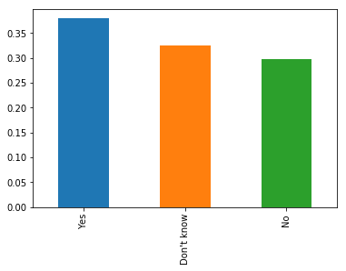

```python
df.benefits.value_counts(normalize=True).plot.bar()
```

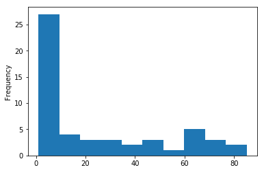

```python
df.Age.value_counts().plot.hist()
```

### Q8: Experiment with the number of bins in the histogram of the Age distribution:

Hint: use the bins= option to plot()

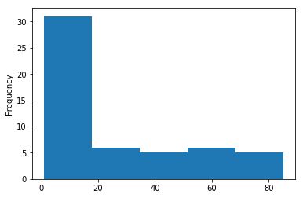

```python
df.Age.value_counts().plot.hist(bins = 5)
```

## Discretization and Binning

Discretization of continuous variables can potentially enhance the goodness-of-fit of a statistical model. Age, for example, is a common varaible to be categorized.

### Q9: Discretize the age into bins (16,21], (21,25], (25,30], (30, 35], (35,40], (40,50], (50,60], (60,).

How many respondents are in each range? Hint: create a list of bin values Hint: use pd.cut() Hint: use value_counts()

```python
bins = [15,20,25,30,35,40,50,60,200]
```

```python
pd.cut(df['Age'], bins).value_counts()
```

```
(25, 30]     362
(30, 35]     339
(20, 25]     195
(35, 40]     185
(40, 50]     122
(50, 60]      22
(15, 20]      22
(60, 200]      4
Name: Age, dtype: int64
```

## Aggregation

Example: Find the size of each Age group.

Solution:

```python
df.groupby('Age').size()
```

```
Age
-1726            1
-29              1
-1               1
 5               1
 8               1
 11              1
 18              7
 19              9
 20              6
 21             16
 22             21
 23             51
 24             46
 25             61
```

[output cut: 40 more lines]

### Q10: Find the median age of each state.

```python
pd.DataFrame(df,columns=['state', 'Age']).groupby('state').median()
```

| state | Age |
| --- | --- |
| AL | 34.0 |
| AZ | 33.0 |
| CA | 31.0 |
| CO | 31.0 |
| CT | 37.5 |
| DC | 37.5 |
| FL | 34.0 |
| GA | 30.0 |
| IA | 40.0 |
| ID | 55.0 |
| IL | 30.0 |
| IN | 34.0 |
| KS | 39.0 |
| KY | 24.0 |
| LA | 35.0 |
| MA | 32.0 |
| MD | 29.0 |
| ME | 40.0 |
| MI | 34.0 |
| MN | 30.0 |
| MO | 33.5 |
| MS | 33.0 |
| NC | 32.0 |
| NE | 26.0 |
| NH | 34.0 |
| NJ | 32.0 |
| NM | 29.5 |
| NV | 28.0 |
| NY | 29.0 |
| OH | 31.0 |
| OK | 26.5 |
| OR | 32.0 |
| PA | 31.0 |
| RI | 23.0 |
| SC | 30.0 |
| SD | 34.0 |
| TN | 33.0 |
| TX | 31.5 |
| UT | 28.0 |
| VA | 40.5 |
| VT | 34.0 |
| WA | 32.5 |
| WI | 33.0 |
| WV | 23.0 |
| WY | 41.5 |

# Part 2 (on your own): Exploration of Movie Titles and Movie Cast

## Time to load some data:

```python
titles = pd.read_csv('data/titles.csv', index_col=None)
```

The titles DataFrame contains a list of movie titles and release year

```python
cast = pd.read_csv('data/cast.zip', index_col=None)
```

The `cast` DataFrame contains the following columns

**title** = name of movie

**year** = year of movie

**name** = name of actor/actress

**type** = actor or actress

**character** = character name

**n** = number in the credits (NaN when not available)

```python
titles.head()
```

|  | title | year |
| --- | --- | --- |
| 0 | The Rising Son | 1990 |
| 1 | The Thousand Plane Raid | 1969 |
| 2 | Crucea de piatra | 1993 |
| 3 | Country | 2000 |
| 4 | Gaiking II | 2011 |

```python
cast.sample(5)
```

|  | title | year | name | type | character | n |
| --- | --- | --- | --- | --- | --- | --- |
| 2783024 | Tire au flanc | 1928 | Fridette Fatton | actress | Georgette | 11.0 |
| 1991174 | The Primitive Call | 1917 | Lewis Sealy | actor | John Malcolm | 5.0 |
| 812680 | Le avventure di Mary Read | 1961 | Loris Gizzi | actor | Prison Director | 14.0 |
| 2069496 | Inexplicable Epiphanies | 2013 | Warren (XXIII) Smith | actor | Deputy | 15.0 |
| 3170968 | Man elsker kun en gang | 1945 | Randi Michelsen | actress | Olga Ish?j | 4.0 |

### Q11: How many entries are there in the cast table?

```python
len(cast)
```

```
3634467
```

### Q12: How many entries are there in the titles table?

```python
len(titles)
```

```
232330
```

## Some basic analyses

### Q13: What are the two earliest movies?

```python
df_q13 = titles.sort_values('year')
df_q13.head(2)
```

|  | title | year |
| --- | --- | --- |
| 177757 | Miss Jerry | 1894 |
| 215272 | The Startled Lover | 1898 |

### Q14: How many movies have the title "Hamlet"?

```python
df_q14 = titles[(titles['title'] == 'Hamlet')]
len(df_q14)
```

```
18
```

### Q15: List all of the "Treasure Island" movies from earliest to most recent

```python
df_q15 = titles[(titles['title'] == 'Treasure Island')].sort_values('year')
df_q15
```

|  | title | year |
| --- | --- | --- |
| 206027 | Treasure Island | 1918 |
| 51287 | Treasure Island | 1920 |
| 191050 | Treasure Island | 1934 |
| 96934 | Treasure Island | 1950 |
| 89534 | Treasure Island | 1972 |
| 111343 | Treasure Island | 1973 |
| 205397 | Treasure Island | 1985 |
| 179354 | Treasure Island | 1999 |

### Q16: List the supporting roles (having n=2) played by Cary Grant in the 1940s,

in order by year.

```python
#(cast.year >= 1940) & (cast.year < 1950)
#(cast.year == 1940) | (cast.year == 1941)...
# cast.year // 10 == 194
df_q16 = cast[(cast['n'] == 2) & (cast['year']//10 == 194) & (cast['name'] == 'Cary Grant')]
df_q16
```

|  | title | year | name | type | character | n |
| --- | --- | --- | --- | --- | --- | --- |
| 845513 | My Favorite Wife | 1940 | Cary Grant | actor | Nick Arden | 2.0 |
| 845523 | Penny Serenade | 1941 | Cary Grant | actor | Roger Adams | 2.0 |

### Q17: What are the ten most common movie names of all time?

```python
titles.title.value_counts().head(10)
```

```
Hamlet                  18
Carmen                  16
Macbeth                 15
Maya                    12
The Outsider            12
The Three Musketeers    11
Temptation              11
Kismet                  11
Freedom                 11
Othello                 11
Name: title, dtype: int64
```

### Q18: Plot the number of "Hamlet" films made each decade

Make sure your decades are in chronological order on the x-axis

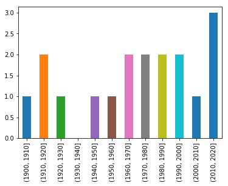

```python
bins = list(range(1900,2030,10))

df_q18 = titles[(titles['title'] == 'Hamlet')]

pd.cut(df_q18['year'], bins).value_counts().sort_index().plot.bar()
```

### Q19: Who are the 10 people most often credited as "Herself" in film history?

```python
cast[cast['character'] == 'Herself'].name.value_counts().head(10)
```

```
Queen Elizabeth II    11
Joyce Brothers         9
Margaret Thatcher      8
Hillary Clinton        7
Mary Jo Pehl           7
Sumie Sakai            6
Joan Rivers            6
Kareena Kapoor         5
Bunny Yeager           5
Rekha                  5
Name: name, dtype: int64
```

### Q20: What are the 10 most frequent roles that start with the word "Science"?

Hint: read docs on str.startswith()

```python
cast[cast['character'].str.startswith('Science')].character.value_counts().head(10)
```

```
Science Teacher         60
Science Student          9
Science Fair Student     9
Science Fair Judge       6
Science Reporter         5
Science Kid              5
Science Club Member      5
Science Promo Cadet      5
Science                  4
Science Officer          3
Name: character, dtype: int64
```

### Q21: How many leading (n=1) roles were available to actors, and how many to actresses, in the 1950s?

```python
print(len(cast[(cast['type']=='actor') & (cast['n']==1) & (cast['year']//10==195)]))
print(len(cast[(cast['type']=='actress') & (cast['n']==1) & (cast['year']//10==195)]))
```

```
6616
2965
```

### Q22: How many supporting (n=2) roles were available to actors,and how many to actresses, in the 1950s?

```python
print(len(cast[(cast['type']=='actor') & (cast['n']==2) & (cast['year']//10==195)]))
print(len(cast[(cast['type']=='actress') & (cast['n']==2) & (cast['year']//10==195)]))
```

```
4564
4556
```

### Q23: Comment on the differences in gender ratios for leading vs. supporting roles in the 1950s. Does there appear to be a bias?

```python
Yes, women tend to be supporting roles instead of leading roles back in the 1950s. There is some gender bias.
```

[output not shown]